# Evaluación final

## Examen del curso “Fundamentos básicos del lenguaje R”

Este examen involucra la carga de datos, su exploración, manipulación y posterior utilización para la producción de gráficos, tal como hemos visto a lo largo del curso. Para su realización se pueden consultar todos los materiales del curso y las ayudas internas de R. Sin embargo, por razones obvias, **no está permitido realizar consultas *online* o asistencia con *IA***.

Al final, debe entregar un script de R correctamente indexado. Utilice los comentarios para explicar brevemente cada línea o bloque de código, así como para explayarse en la explicación de alguna sección.

### Carga y exploración de los datos

Utilizaremos un conjunto de datos que contiene datos de mediciones diarias de la calidad del aire en Nueva York en el período de mayo a septiembre de 1973.

1. [Descargue el archivo zip](https://github.com/pastornicolas/fundamentos_R/raw/refs/heads/main/dia2/data/data_ev.zip) y extraiga los dos archivos de texto: “air_quality.csv” y “humidity.csv”.
2. Cargue la tabla contenida en el archivo “air_quality.csv” en un nuevo objeto llamado “air_quality” y muestre las primeras 8 filas.
3. Muestre las últimas 6 filas.
4. Imprima el nombre de todas las columnas.
5. Mencione de qué tipo es cada variable.

### Manipulacion de los datos

6. Modifique la tabla para que las columnas que refieren al mes y al día sean la 1° y 2° columna, respectivamente.
7. La tabla contenida en el archivo “humidity.csv” indica los valores de humedad relativa del aire para cada día y mes. Cargue la tabla e incorpore estos datos a la tabla trabajada hasta ahora.
8. Quite todos los casos con valores `NA`.
9. Ordene la tabla de manera creciente por mes y por día, en ese orden.
10. Convierta los meses, indicados con número, a texto indicando su nombre (e.g. 5 = “Mayo”) y transforme la columna conteniendo estos datos a factor.
11. Reescriba el nombre de las filas para que el nombre de cada fila coincida con su verdadera posición.
12. Cree una nueva columna llamada “TempC” que sea la temperatura en grados Celsius, ya que la columna existente en la tabla contiene esta información pero en grados Fahrenheit. La fórmula que relaciona ambas unidades es: `°C = (°F - 32) / 1.8`

### Funciones

13. Construya una función que haga la conversión de °F a °C y que la misma contemple un escenario donde el usuario no ingresa números.

### Gráficos

Para realizar la siguiente sección puede utilizar el sistema gráfico que prefiera (R base o *ggplot2*).

14. Realice un gráfico de cajas (boxplot) de la variable `Solar.R` por mes de Mayo a Septiembre, en ese orden.
15. Etiquete los ejes con nombres en español y agregue un título relevante. Utilice un color único para todas las cajas. Fuera de estas indicaciones, personalice el gráfico a su gusto.
16. Realice un gráfico de dispersión (*scatterplot*) entre `Ozone` y `TempC`. Personalízelo de manera que el gráfico final sea lo más similar posible a la siguiente figura:

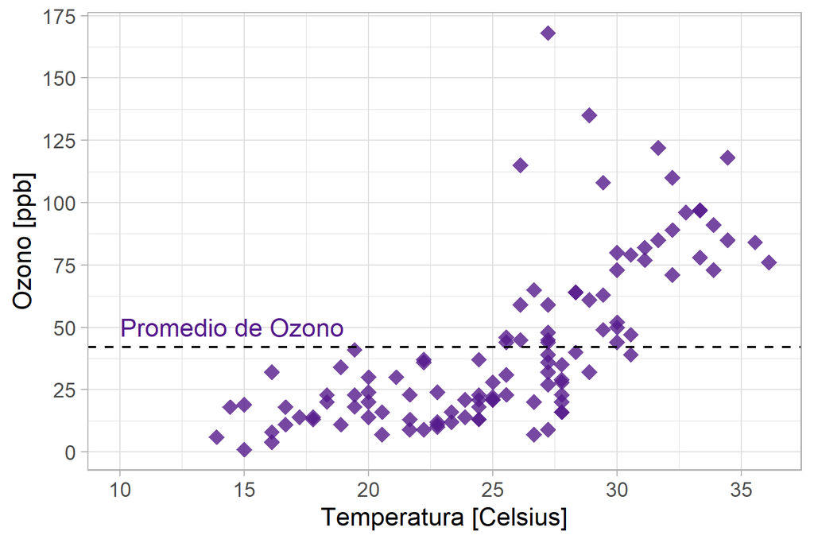

17. Exporte todos los gráficos realizados a formato `png` con una resolución de 300 ppi, 1500 pixeles de ancho y 1000 pixeles de alto. Los archivos deberán llamarse “Gráfico_1.png” y “Gráfico_2.png”.

#### Ejercicio para puntos extra

- Mediante un bucle `for`, cree una nueva columna en la tabla air_quality llamada `Solar.R.accum`. La misma debe representar la radiación acumulada día a día.

### Evaluación

Envíe todos los archivos (script y gráficos), preferentemente comprimidos en un archivo zip, a la dirección pablo.huais@unc.edu.ar. Indique como asunto “APELLIDO Y NOMBRE: evaluación curso”. En un escenario ideal, el script debería correr sin errores y seguir adecuadamente las consignas de la evaluación. **No obstante, a no preocuparse demasiado, ya que se considerarán los intentos realizados!**

### Debate final

Discutiremos sobre el rol que R ocupará en nuestras vidas en compañía de cerveza y/u otras bebidas espirituosas!

[figure not shown]